# League of Legends: Understanding Gameplay Dynamics

Tamana Yaqoubi & Veronica Alviso

2025-12-08

# **Introduction**

The first video game was created in 1952, and since then, games have evolved from simple strategic concepts to more complex and immersive gameplay. League of Legends is considered one of the world’s most popular multi-player online battle arena (MOBA) games. Even games that are supposed to be considered “fun” can also become highly competitive and rewarding. In this report we aim to uncover what it takes for a team to win, both through individual player performance and overall team coordination and decision making.

**Main Objective:**

What are the key predictors of winning a League of Legends match?

**Research Questions:**

- How does game duration influence total kills and win rates?
- Which champions are most played, and which champions win the most?
- How do player ranks differ in game play patterns and outcomes?
- How do predictors of victory differ across queue types?

Diving into the data provided, our goal is to provide comprehensive statistical analysis of the factors that may influence a victory in League of Legends. The data features 35,000 matches and over 78,000 player records, covering various in-game aspects such as champion selection, item usage, lane dynamics, and gameplay variation across rank and queue type. We aim to identify patterns and strategies that have a strong correlation to winning . We hope to not just predict a win but also to provide reasons as to why these factors matter.

# **About the Dataset**

[League of Legends Matches Dataset](https://www.kaggle.com/datasets/nathansmallcalder/lol-match-history-and-summoner-data-80k-matches)

The data used in this project comes from Kaggle. We joined some of our CSV to have more efficient data structure.

Our combined data sets are as follow:

- **MSI_tbl:** This table is a combined version of MatchStatsTbl and ItemTbl. The purpose for joining these tables is to connect in-game performance data with the items purchased by players.
- **Match_rank_tbl:** This table is created from joining the MatchTbl and RankTbl. The purpose of joining the tables is to connect player skill level with match performance.
- **TMR_Tble:** The table is a combined version of TeamMatchTbl and MatchTbl. The purpose for joining these tables is to see team outcomes for every match.
- **SMR_Tbl:** The purpose for joining SummonerMatchTbl and RankTbl is to see individual players and their rank level.
- **Team_Winner_Tbl:** The purpose for creating this table is that it shows teams that have won from TMR_Tble.

### **Tools and functions used**

The following are some of the R packages and tools we utilized for efficient data visualization and performance enhancement.

- **Dplyr:** An R package that is used for selecting, filtering, summarizing, and storing data.
- **Ggplot2:** We used this R package to visualize our data in the form of graphs and charts.
- **Plotly:** Used in making interactive graphs that help explore data visualization.
- **Kable Extra:** Used for manipulating table styles and creating well-formatted tables.
- **Grid Extra:** Used for displaying and arranging multiple visualizations in a single grid.
- **Joined Functions:** Used for combining and creating new tables from existing tables and datasets.

# **Map and Team Dynamics**

We will examine how factors such as average, maximum kills relate to a team’s likelihood of winning, comparing outcomes across both sides of the map. We also explore how game duration is associated with these performance metrics. The categorical features analyzed are:

- Queue Type (Classic, Aram, SwiftPlay, Ultbook, Cherry(Arena))
- Epic Monsters ( Baron, Rift Herald, Dragons)
- Enemy Kills (Red Kills, Blue Kills)
- Tower
- Team ( Red and Blue)
- Game Duration (seconds)

### **Kill Distribution Analysis: Average and Maximum**

**What can be killed in league of legends?**

- **Baron:** “The most power neutral monster on Summoners Rift”
  - 300/+25 gold per teammate
  - Experience 600/+800 ( damage increases)
  - Empowers nearby minions
- **Rift Herald:** Upon killing drops an eye of the Herald, which can be picked up by one member of the slayers team, and used to summon Rift Herald Mercenary for structural (Tower) damage.
  - Grants 100 gold
- **Dragons:** They grant rewards upon killing them
  - Experience
  - Bonus stats based on their element type
  - Dragon stack, granting the dragon soul at 4
- **Towers:** Protect each lane and deal high damage to enemy champions, making them a key defensive structure
  - Destroying turrets grants gold and opens the map
- **Enemy Champions:** The opposite team consist of 5 members (Champions)
  - Grants gold
  - Experience
  - Creates an imbalance on the map
- **Minions:** Soldiers from the opposite that can cause damage to champions and towers
  - Grants gold
  - Experience

|  | Side | Queue Type | Mean Kills | Min Kills | Max Kills | Mean Baron | Min Baron | Max Baron | Mean Rift Herald Kills | Min Rift Herald Kills | Max Rift Herald Kills | Mean Dragon Kills | Min Dragon Kills | Max Dragon Kills | Mean Tower Kills | Min Tower Kills | Max Tower Kills |
| --- | --- | --- | --- | --- | --- | --- | --- | --- | --- | --- | --- | --- | --- | --- | --- | --- | --- |
| 1 | Blue | ARAM | 62.21505376344086 | 0 | 124 | 0 | 0 | 0 | 0 | 0 | 0 | 0 | 0 | 0 | 3.733870967741935 | 0 | 4 |
| 2 | Blue | CLASSIC | 35.16272646031359 | 0 | 91 | 0.5733203347144366 | 0 | 5 | 0.6736534243236656 | 0 | 1 | 2.436184905353806 | 0 | 7 | 8.390689739215208 | 0 | 15 |
| 3 | Blue | SWIFTPLAY | 34.27896995708154 | 0 | 62 | 0.4721030042918455 | 0 | 2 | 0.4978540772532189 | 0 | 1 | 1.931330472103004 | 0 | 4 | 9.412017167381974 | 0 | 21 |
| 4 | Blue | ULTBOOK | 42.25 | 34 | 53 | 0.5 | 0 | 1 | 0 | 0 | 0 | 3 | 3 | 3 | 9 | 7 | 10 |
| 5 | Red | ARAM | 63.33964879852126 | 0 | 120 | 0 | 0 | 0 | 0 | 0 | 0 | 0 | 0 | 0 | 3.767097966728281 | 0 | 4 |
| 6 | Red | CLASSIC | 35.58519269776876 | 0 | 136 | 0.6346348884381339 | 0 | 4 | 0.5533299526707235 | 0 | 1 | 2.77789046653144 | 0 | 8 | 8.403228532792427 | 0 | 16 |
| 7 | Red | SWIFTPLAY | 34.23595505617978 | 0 | 56 | 0.6460674157303371 | 0 | 3 | 0.4719101123595505 | 0 | 1 | 2.106741573033708 | 0 | 5 | 9.5561797752809 | 0 | 18 |
| 8 | Red | ULTBOOK | 45.57142857142857 | 34 | 59 | 0.5714285714285714 | 0 | 1 | 0 | 0 | 0 | 3.428571428571428 | 2 | 5 | 8.571428571428571 | 4 | 11 |

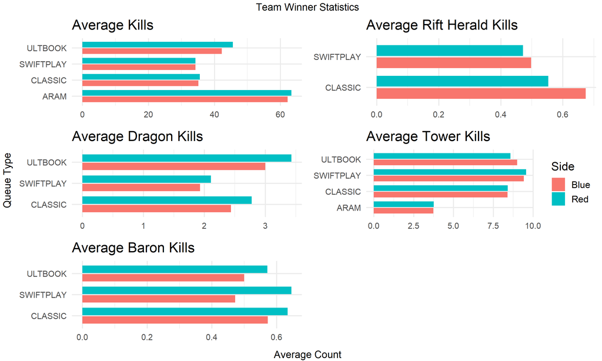

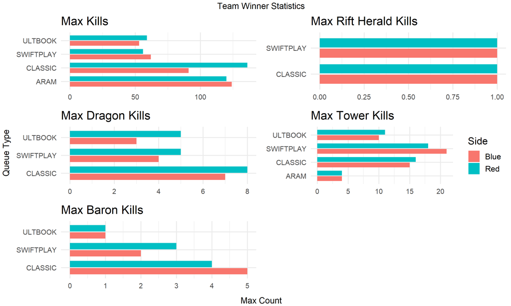

Overall, the kill patterns observed in the plots are consistent with each queue type and their respective objectives, spawning times, and intended game play style. Which should be considered when comparing performance across queue types.

## **Analysis of Game Duration Distribution**

**How does game duration influence total kills and win rates?**

To better understand how time impacts performance across queue types, we will dive into describing each mode and the map each one is played on with some key features.

- **Classic:** Played in summoner’s rift map
  - Standard 5v5 game mode
  - Features three lanes, a jungle, and epic objectives(Dragons, Rift Herald, Baron)
  - Player can select champion
  - Emphasize teamwork, macro strategy, coordinated objective control
  - Longer games
- **Aram:** Played in Howling Abyss map
  - Stands for All Random All Mid
  - Fast paced
  - 5v5 game mode
  - Features a single lange, generates random champion per player
  - Focuses entirely in combat and destruction of nexus
- **Swiftplay:** Played in summoner’s rift map
  - Game pace is accelerated
  - Designed for faster games; 5v5 game mode
- **Ultbook (Ultimate Spellbook):** Played in summoner’s rift map with modified rules
  - Gameplay is more chaotic, ability focused and unpredictable
  - Traditional rules but less centric
  - Temporary game mode
- **Cherry (Arena):** Played on custom arena map
  - Features no lanes and removes traditional objectives
  - Combat rounds only
  - 2v2v2v2
  - Success depends on champion combat strength, adaptation, item optimization

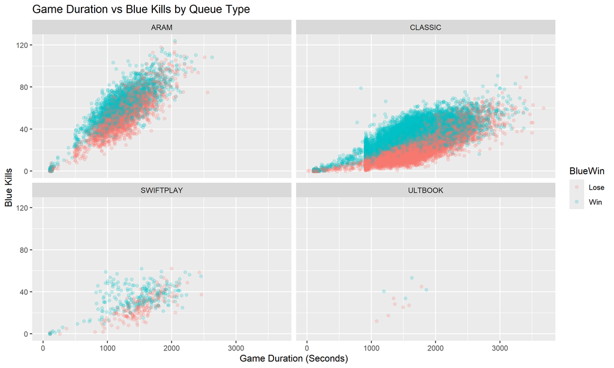

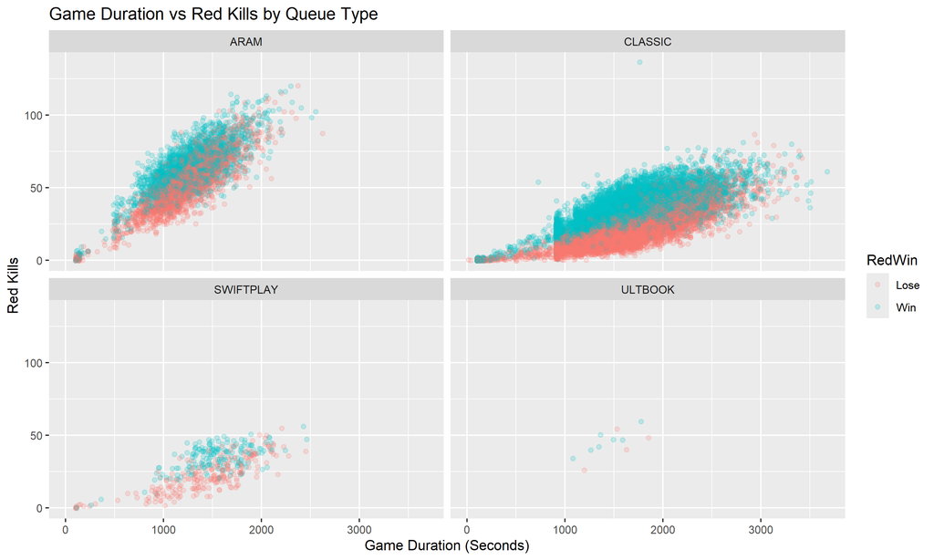

Across all queue types, there is a strong relationship between game duration and the number of kills.

- Shorter games lead to low kill counts
- Longer games lead to high kill count

Regardless of the team, the pattern appears on both red and blue teams, indicating that the number of kills is not based on team side but on how long the match lasts. Early kills, however, play a more decisive role in shaping the outcome of a match. In both Red and Blue team plots we can see that a winning team tends to get more kills early on in the game. This is due to early kill advantages such as gold and experience which leads to map and lane pressure. Although longer game duration does lead to more kills, the plot suggests that their importance becomes minuscule leading to smaller gaps of winning and losing teams and less kill advantage.

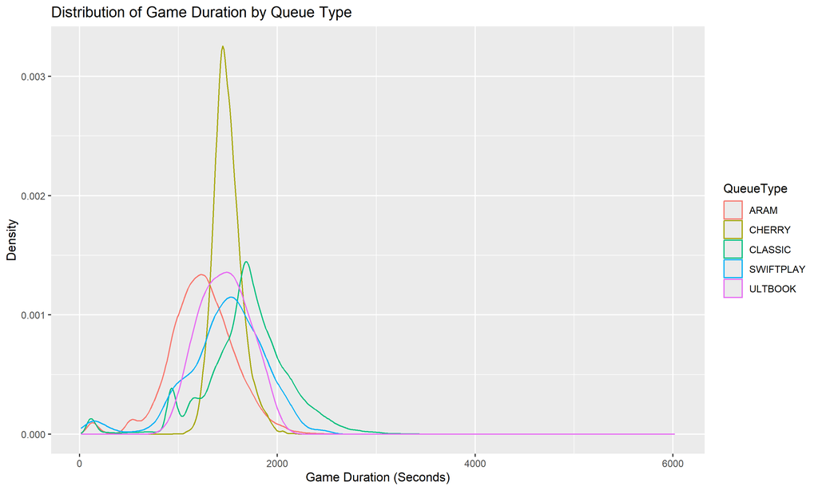

The density plot above displays distinct differences between each queue type.

This influences how games play out, shaping the patterns and interactions that are done both individually and as a team which can help determine if a team wins or loses

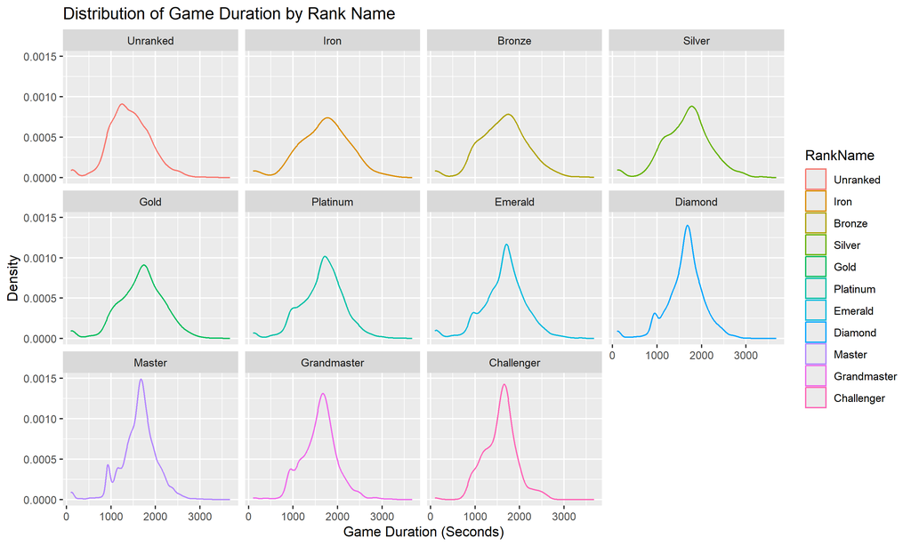

A rank name in League of Legends represents the player’s skill level, ranging from Iron the lowest to Challenger the highest. The rank names can be categorized as lower ranks, middle ranks, and high ranks. League of Legends also has unranked players who have not yet been assigned a rank, they are new players, or are players in placement games.

- **Lower rank:** Includes Iron, Bronze, and Silver that represent newer or unskilled players
- **Middle rank:** Indudes Gold, Platinum, and Emerald that represent average skilled players
- **High rank:** Includes Diamonds, Master, Grandmaster, and Challenger that represent very high skill and experienced players

The density plot above shows game duration across different ranks in the game. The plot indicates how frequently certain match lengths occur within each rank. Lower and middle ranks show wider distributions and longer average game duration that shows less consistent game play. Some games in the lower ranks often last approximately 40 minutes. The higher ranked games are more focused and show more consistent match lengths, faster decision making, and overall efficient game control.

# **Individual Gameplay Dynamics**

In this section we will focus on individual performance by analyzing kill patterns, gold and vision scores. Through further evaluating their deaths, item choices and champion selection.

- **Role:** Map positions or lane roles within a queue type (Aram and Cherry do not have Lane roles)
- **Gold:** Purchasing power to buy items
- **Vision Score:** Players contribution to map awareness through ward placement.
- **Champion Selection:** Determines the role, offers unique abilities (strengths and weaknesses)
- **Items:** Enhance champion stats and abilities (defense and offensive play style)

### **Kill Distribution Analysis: Lane Performance**

The map in League of Legends has three main lanes, top, middle, and bottom, and a jungle that goes from between the lanes. Champion types and responsibilities differ in each lane

**Top Lane:** The uppermost and solo lane where the player is isolated from its team. Tanks, fighters, and Split-pushers are the typical champions for this lane. The goal for the players in the top lane is to collect more gold, survive their lane, and become strong to help their teams later in the game.

**Middle Lane:** The central solo lane where players can easily roam and reach the top and bottom lanes and also help the jungler player. Typical champions for this lane include fighters, mages, and assassins. The mid laner’s goal is to roam to other lanes, far minions, and kill the lane opponent.

**Bottom Lane:** Unlike the other lanes, it is the duo lane: the Attack Damage Carry (ADC) and the Support.

**ADC**

- Has moderate to high kill distribution
- Needs gold and items to become strong
- It is weak early in the game and becomes stronger later to carry the team
- Their main goal is to farm minions and deal damage
- Jinx, Ashe, Miss Fortune, Vayne, and Caitlyn are some of the most popular bottom champions

**Support**

- Protects ADC and help team win fights
- Controls vision by placing wards, clearing enemy wards, and buying more wards
- Support champions are Tank, Healing, and Damage supports

**Jungle Lane:** Jungler is not in a specific lane and instead the jungle player moves to different lanes to watch for enemies, warn teammates of any attack, and steal camps. Unlike the main lane players,the jungler kills the jungle monsters instead of minions for more gold, helps the main laners to win, and controls major objectives, such as dragons, rift herald, and baron Nashor. They try to kill wolves, blue and red buff, raptors, and krugs to get gold and experience. Some of the common jungle champions are

- Assassins: Evelynn and Kha’Zix
- Tanks: Amumu, Sejuani
- Fighters: Lee Sin

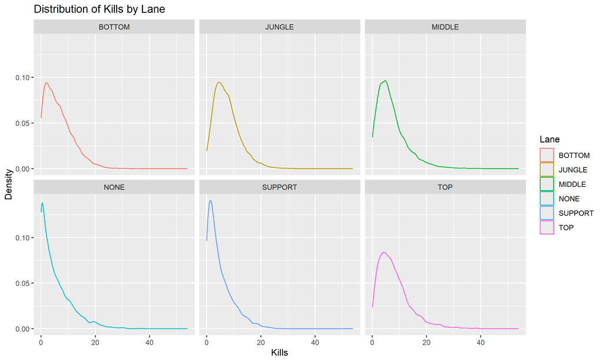

[interactive chart not shown]

The graph shows the total number of kills in each lane across all games. Our plot indicates that the top lane has the most kills because the top lane is a 1v1 lane with frequent trade and jungle attacks. Total kills for middle and bottom lanes are similar with only some difference between them. This is expected because middle laners roam into the other lanes and help them with fights and kills, and the bottom lane is a 2v2 match where Support helps them win a fight. Support has the least number of kills, which is expected because Support concentrates on controlling vision and protects teammates instead securing kills. Game duration significantly impacts kill distribution across all games as Longer games tend to have more kills due to longer teamfights. Queue types also impact total kills because some queue types are more competitive than the others.

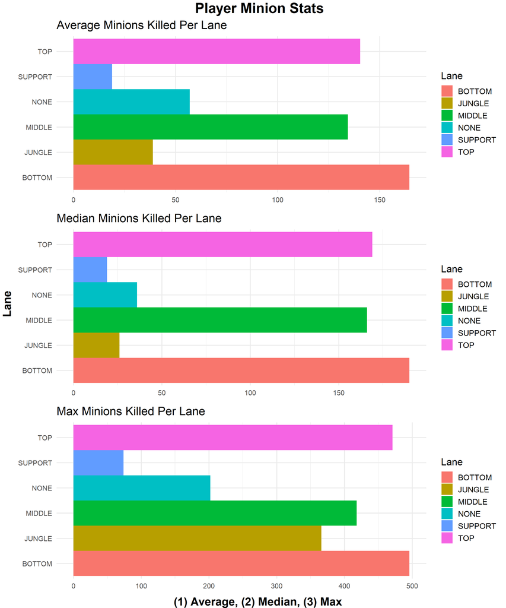

- Bottom lane has the highest average and maximum of minions killed per lane
- It is expected because bottom is duo player and one player always roam and help the team with fights and kills

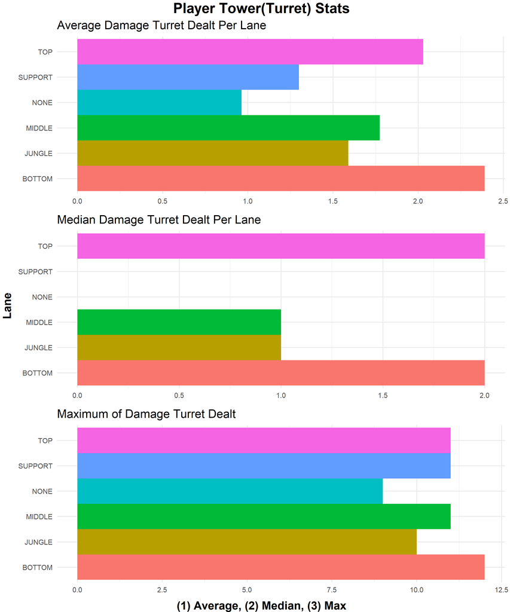

- Bottom lane has the highest average and maximum of total damage done to enemy’s tower during a match
- It is possible because the bottom role is designed in a way where one player is farming and gets most gold and the other player protects and helps with fights.

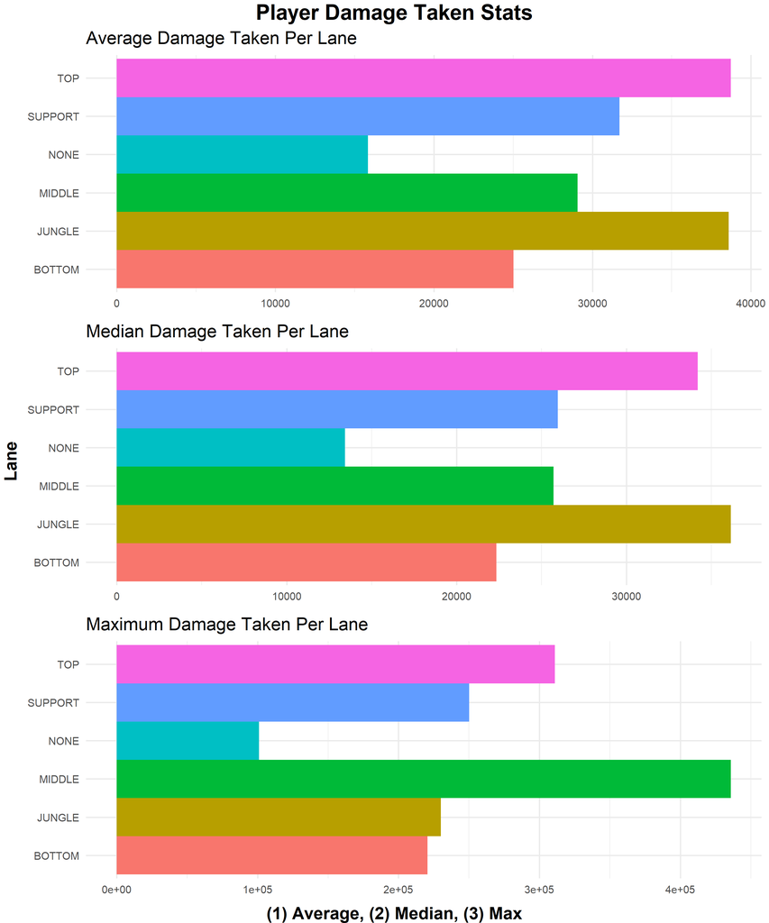

- The top lane has the highest average of damage taken. It is expected because it is 1v1 and an isolated lane far from safety.
- The middle lane has the maximum damage taken because of its location in the center of the map, it is more involved in more fights, and most of the time it gets ganked by jungle players.

### **Gold Distribution Analysis**

Gold is imperative in the game of league of legends, making it a much needed resource to scale throughout the game. Our previous data examined players’ damage dealt, now we will examine if gold influences damage and how gold varies across lanes.

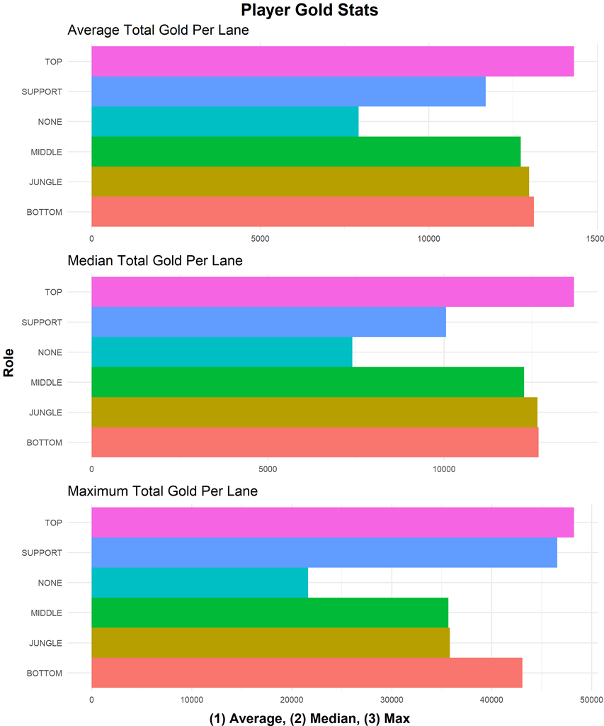

The bar graphs above reveal that Top lane tends to earn the most gold out of all the lanes, followed by Bottom then Jungle. Isolated lanes like top lane and middle lane are bound to receive more gold if properly farmed.

- Staying prolonged times in your lane or isolated while farming increases your gold income.

**So why is the bottom role second, if it is not an isolated lane?** This is due to their role, they prioritize farming earlier in the game, this is also why support will have the lowest gold, their role is to make sure your bottom player is getting all the gold they can through enemy kills, minion kills, and objective tasks by protecting them from any attacks.

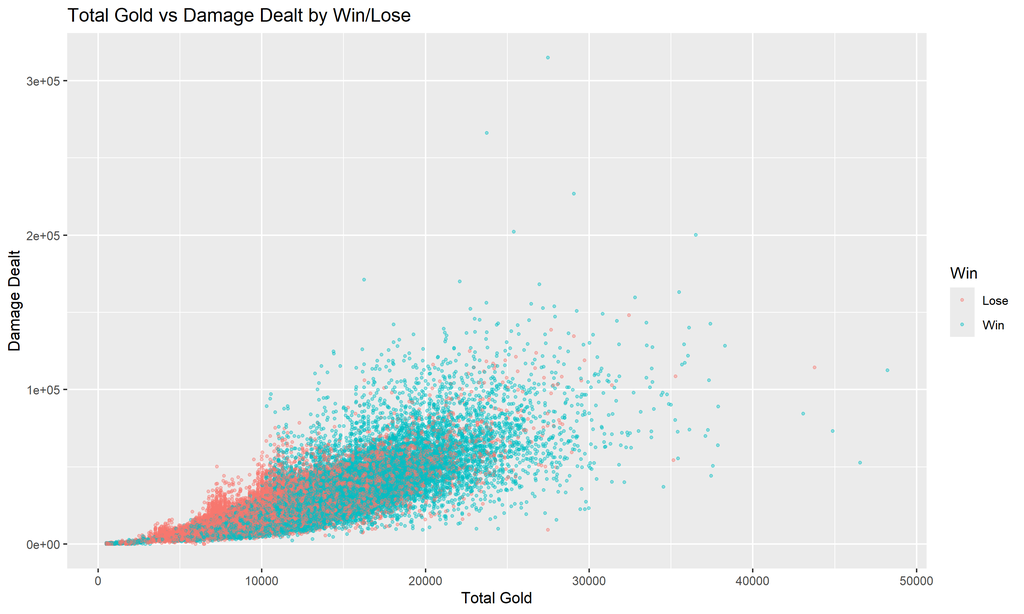

The scatter plot above reveals that as gold increases, the damage dealt also increases. Suggesting that players with more gold will end up purchasing meaningful items that will lead to more damage. It also reveals that winning teams(blue) usually have more gold than losing teams (red), supporting the idea of gold advantage increases your probability of winning.

- **Key details:** Losing team that have damage advantage with little gold can be due to individual player performance or champion selection
  - Some champions do a lot of damage with little to no items

### **Vision Score Analysis**

Vision score provides insight to an individual’s strategic gameplay and team cordination by measuring their contribution to map control and map awareness. To understand the importance of placing wards (vision trinkets) and maintaining vision, we evaluated and compared vision scores between winning and losing teams, examined how kills relate to vision score and identified lane patterns by analyzing both kills and deaths across roles.

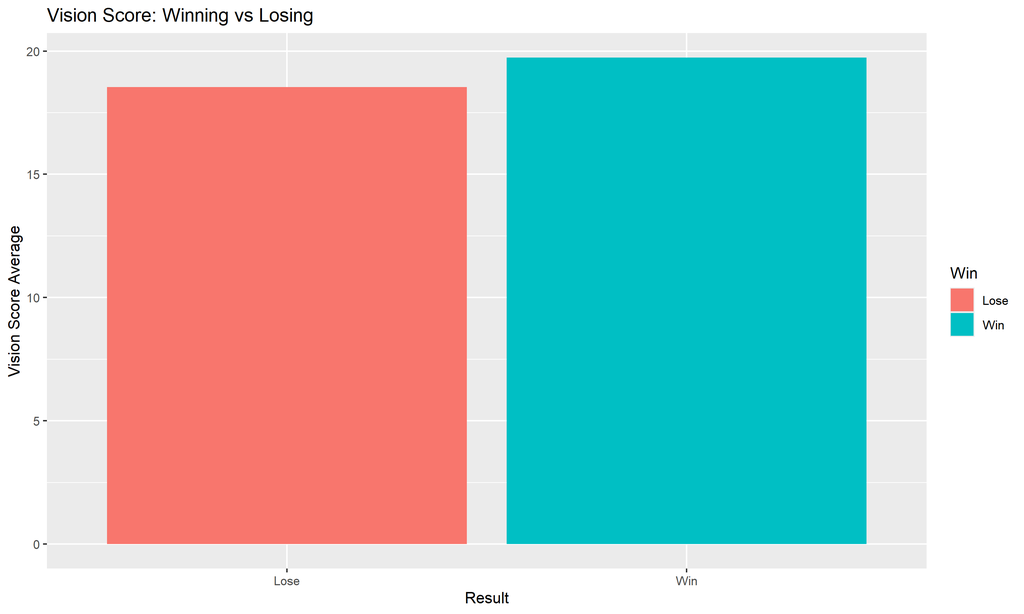

The bar chart above compares both winning and losing teams and shows that even though there is not a dramatic difference, it suggests that players on the winning side generally contribute more to vision control.

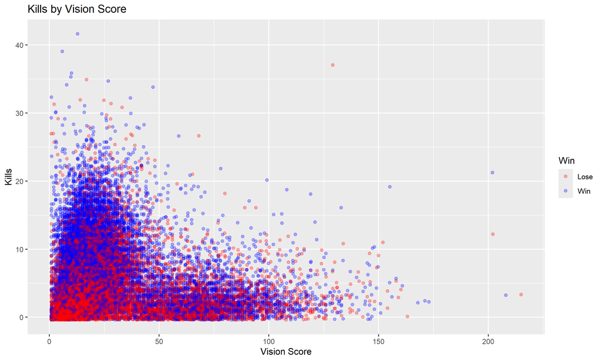

The scatter plot above reveals that lower vision is strongly associated with higher kill counts, the cluster of kills between 20 to 40 are found in vision scores between 0 to 30. As vision increases, kills decrease. This pattern reflects role utility through safer decision making when vision is higher by choosing safer pathing, objective control and improved team coordination.

[interactive chart not shown]

Kills vary by lane role but overall kills are higher at low vision scores and decrease as vision increases. As the game progresses, some roles see a spike in kills, while others are unaffected by the vision increase. For example, the bottom doesn’t see a huge spike like support or middle lane players, this is because they are meant to stay in the backline and only wander the map with other members and not by themselves. Support on the other hand their role is to maintain vision for everyone and as the game progresses assist other lanes like middle lane, in order to play more aggressively.

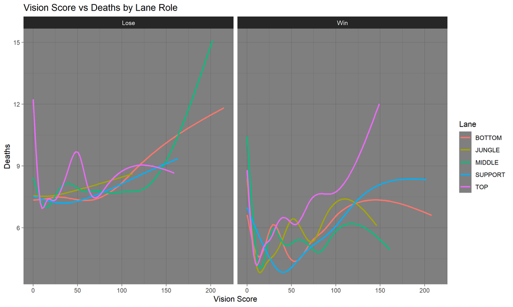

### **Item Frequency Analysis**

Item selection plays a key role in champion performance and overall team success. In order to understand the players’ build, we explored the frequency of item usage by identifying the top ten, bottom 10 and the mean and median of item choices across all players.

```
## [1] "least popular item"
```

| ItemNames | Total_Items |
| --- | --- |
| Bounty of Worlds | 1 |
| Catalyst of Aeons | 1 |
| Chemtech Putrifier | 1 |
| Lifeline | 2 |
| Elixir of Force | 3 |
| Elixir of Wrath | 4 |
| Winter's Approach | 5 |
| Your Cut | 6 |
| Prismatic Stat Voucher | 7 |
| Elixir of Sorcery | 8 |

```
## [1] "Mean and Median of items a player holds"
```

| ItemNames | Items_used_avg | Items_used_median |
| --- | --- | --- |
| Infinity Edge | 4516 | 4516 |
| Ionian Boots of Lucidity | 3811 | 3811 |
| Rabadon's Deathcap | 3698 | 3698 |
| Sorcerer's Shoes | 3545 | 3545 |
| Berserker's Greaves | 3512 | 3512 |
| Mercury's Treads | 3115 | 3115 |
| Doran's Blade | 3084 | 3084 |
| Shadowflame | 2670 | 2670 |
| Plated Steelcaps | 2502 | 2502 |
| The Collector | 2447 | 2447 |

The results of this table show that these items are the least likely to be built by players. Some of these items like the elixirs are consumable, making them a 1 to multiple time use but are rarely purchased. Other items are situational and are only relevant to specific matches.

The table above only reveals the mean and medium resulting in the top 10 items.

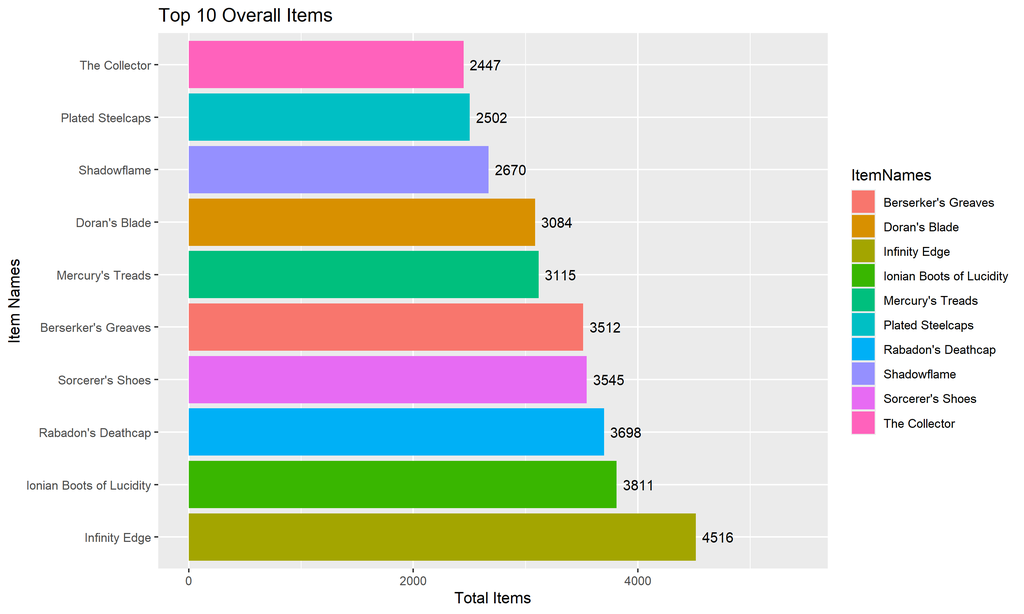

The bar chart above shows the top 10 items most frequently purchased by all players. Items found on this list have specific defensive/offensive enhancements making them dire to builds.

In league of legends, increased movement speed can be achieved through purchase of boots, but different boot types serve different roles. The bar chart shows all available boots for purchase on the top 10, making this item the most important. Lucidity boots become the most popular among all, granting summoner spell haste (cool down reduction on abilities) and movement speed. Many players seek lucidity boots to decrease their ability to cool down, allowing them to use their special attacks more frequently. Other items such as infinity edge are essential for bottom lane users providing critical strike and increasing damage. Doran’s blade is a starter item that is utilized in early stages of the game and is usually purchased acrossed lane roles..

### **Analysis of Champion Popularity and Win Performance**

**Which champions are most played, and which champions win the most?**

Champion selection is one of the most critical components for team coordination. Although the selection per role is massive, not all champions synergize well together, selecting the wrong champion based on your team composition can negatively impact overall performance, costing the team a win. In this section, we examine the most commonly selected champions overall, their popularity across different ranks and their winrate.

[interactive chart not shown]

The bar chart above reveals that the most popular champions are usually used by the bottom lane players.

- Kaisa can be used for both bottom lane and middle lane, depending on her item selection you can have either AP or AD damage, making her popularity no surprise since she can be selected in different roles.
- Caitlyn is the second most played champion, which is predominantly played in bottom lane as well, she has a strong early game presence making her dominant in lane strategies.
- The rest of the champions are relatively close in frequency and serve specific roles such as support, jungle, middle. Suggesting a well balanced distribution of popularity of champions.

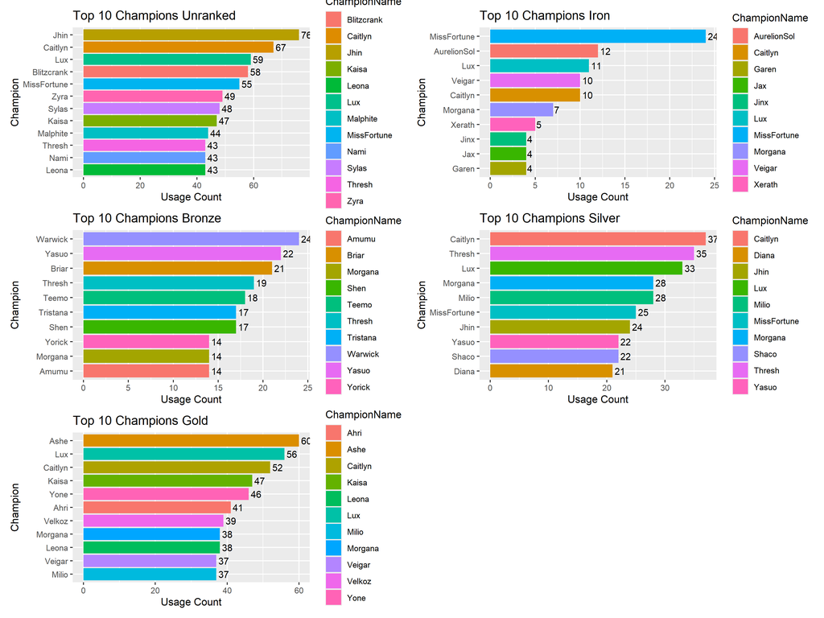

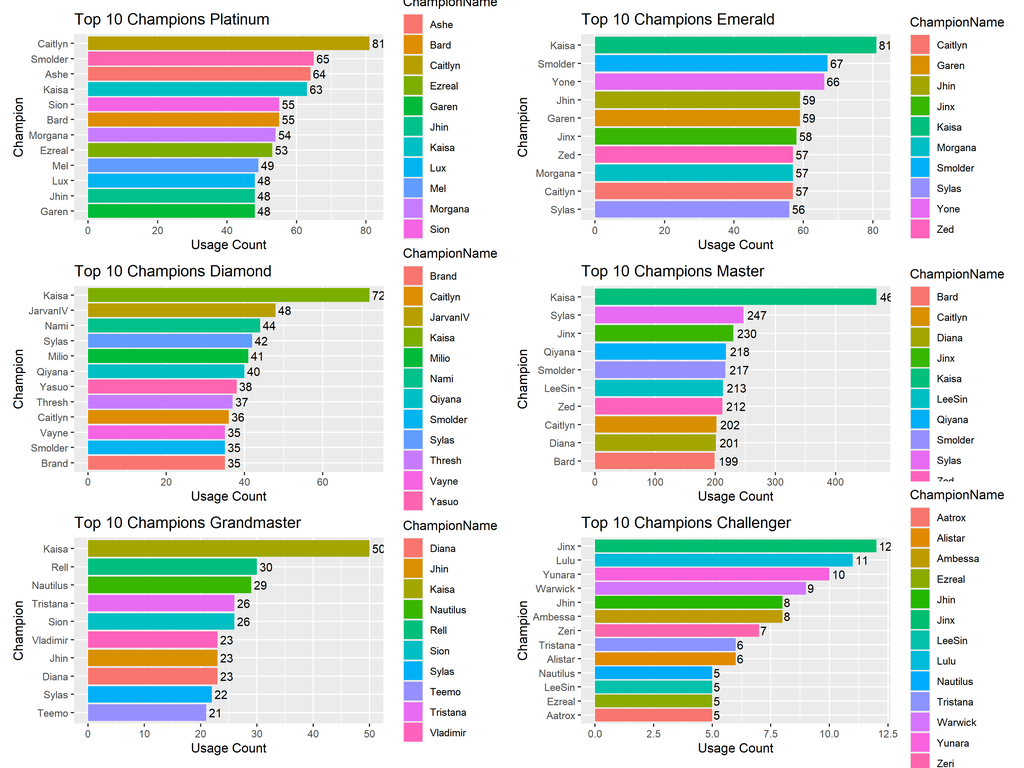

Based on the data above, **lower rank (iron - silver)** share similar champion preferences that are easier to understand and use in team compositions without requiring extensive knowledge.

Although each rank shows similar patterns in champion selection, one rank shows a more diverse and specialized pick. Challenger doesn’t always stick to specific champions but alternates based on the meta.

| ChampionName | Games | Wins | WinRate |
| --- | --- | --- | --- |
| Kalista | 78 | 45 | 0.5769230769230769 |
| Belveth | 85 | 53 | 0.6235294117647059 |
| Lissandra | 110 | 64 | 0.5818181818181818 |
| Kled | 162 | 95 | 0.5864197530864198 |
| Hecarim | 200 | 115 | 0.575 |
| KogMaw | 214 | 126 | 0.5887850467289719 |
| Draven | 244 | 141 | 0.5778688524590164 |
| Galio | 284 | 167 | 0.5880281690140845 |
| Ahri | 316 | 184 | 0.5822784810126582 |
| Tristana | 404 | 233 | 0.5767326732673267 |

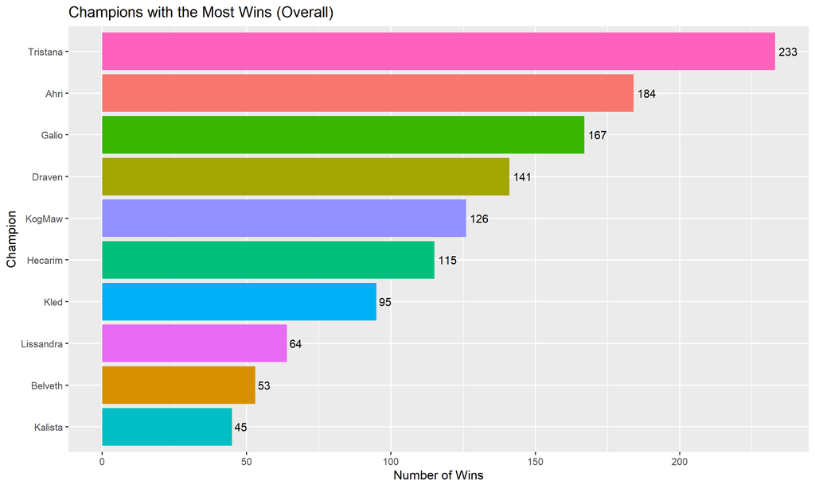

In order to evaluate a more meaningful result, we examined champions that have more than 50 games played and evaluated their winrate.

Belveth has the highest winrate rate with a 62.35%, this champion is typically only played in Jungle roles. The rest of the champions have win rates above 57% marking them slightly higher than a balanced meta winrate of about 50%. Not all of the champions in this table have that many games played aside from Tristana, Ahri, and Galio, some like Kalista have few games played but still have a decent winrate. This suggests that commonly played champions don’t always correlate to winning, but instead depend on other factors such as team compositions and skill.

### **Player Distribution Across Queue Types**

[interactive chart not shown]

The data reveals that most players prefer to play Traditional summoner’s rift (Classic) followed by Arena (Cherry) then Aram. Interestingly enough swiftplay and ultbbook are not usually played even though they are also fast paced game modes. This may be due to their lack of meaningful progression, limited benefits, temporary modes, and minimal impact on a player’s critical and tactical thinking.

[interactive chart not shown]

This chart breaks down the number of players that fall in each category, from highest rank on the left (Challenger) to no rank or low rank on the right (unranked). There is a higher representation of Master players with about 1000 players, other ranks like Emerald, Platinum and Gold have a strong representation ranging between 311 to 473. Unranked also has a strong representation in player distribution, this means that many players choose to not get evaluated and just play game modes that do not affect the status of the rank, it does not necessarily mean that they are low rank players.

The distribution of players is a key finding that supports some of the insights found on other areas of the research. Understanding the distribution of players is crucial because it helps interpret patterns in champion selection, win rates, and performance.

# **Analysis Summary**

### **Implications and Limitations**

**Implications**

- Our findings show that objective control, early-game advantages, gold, and vision management are the strongest predictors of winning
- The result also indicates that teamwork increases chances of winning more than individual attacks and leads to better decision-making, managing attacks, and fighting the enemies.

**Limitations**

- Missing information: Users information was not shared in the dataset.
- Certain data was difficult to extract or analyze, due to inconsistencies in formatting, missing values, or data interpretation.
- Unranked players add ambiguity to performance analysis because their actual skill level is unknown and may overlap with multiple ranked players.